# Red Wine Quality by Wandrille Hubert

```
## [1] "C:/Users/wh1572/Documents/UDACITY/Class With R/Project"
```

# Univariate Plots Section

```
##   X fixed.acidity volatile.acidity citric.acid residual.sugar chlorides
## 1 1           7.4             0.70        0.00            1.9     0.076
## 2 2           7.8             0.88        0.00            2.6     0.098
## 3 3           7.8             0.76        0.04            2.3     0.092
## 4 4          11.2             0.28        0.56            1.9     0.075
## 5 5           7.4             0.70        0.00            1.9     0.076
## 6 6           7.4             0.66        0.00            1.8     0.075
##   free.sulfur.dioxide total.sulfur.dioxide density   pH sulphates alcohol
## 1                  11                   34  0.9978 3.51      0.56     9.4
## 2                  25                   67  0.9968 3.20      0.68     9.8
## 3                  15                   54  0.9970 3.26      0.65     9.8
## 4                  17                   60  0.9980 3.16      0.58     9.8
## 5                  11                   34  0.9978 3.51      0.56     9.4
## 6                  13                   40  0.9978 3.51      0.56     9.4
##   quality
## 1       5
## 2       5
## 3       5
## 4       6
## 5       5
## 6       5
```

```
##  [1] "X"                    "fixed.acidity"        "volatile.acidity"
##  [4] "citric.acid"          "residual.sugar"       "chlorides"
##  [7] "free.sulfur.dioxide"  "total.sulfur.dioxide" "density"
## [10] "pH"                   "sulphates"            "alcohol"
## [13] "quality"
```

```
## 'data.frame':    1599 obs. of  13 variables:
##  $ X                   : int  1 2 3 4 5 6 7 8 9 10 ...
##  $ fixed.acidity       : num  7.4 7.8 7.8 11.2 7.4 7.4 7.9 7.3 7.8 7.5 ...
##  $ volatile.acidity    : num  0.7 0.88 0.76 0.28 0.7 0.66 0.6 0.65 0.58 0.5 ...
##  $ citric.acid         : num  0 0 0.04 0.56 0 0 0.06 0 0.02 0.36 ...
##  $ residual.sugar      : num  1.9 2.6 2.3 1.9 1.9 1.8 1.6 1.2 2 6.1 ...
##  $ chlorides           : num  0.076 0.098 0.092 0.075 0.076 0.075 0.069 0.065 0.073 0.071 ...
##  $ free.sulfur.dioxide : num  11 25 15 17 11 13 15 15 9 17 ...
##  $ total.sulfur.dioxide: num  34 67 54 60 34 40 59 21 18 102 ...
##  $ density             : num  0.998 0.997 0.997 0.998 0.998 ...
##  $ pH                  : num  3.51 3.2 3.26 3.16 3.51 3.51 3.3 3.39 3.36 3.35 ...
##  $ sulphates           : num  0.56 0.68 0.65 0.58 0.56 0.56 0.46 0.47 0.57 0.8 ...
##  $ alcohol             : num  9.4 9.8 9.8 9.8 9.4 9.4 9.4 10 9.5 10.5 ...
##  $ quality             : int  5 5 5 6 5 5 5 7 7 5 ...
```

```
## [1] 1599   13
```

```
##        X          fixed.acidity   volatile.acidity  citric.acid
##  Min.   :   1.0   Min.   : 4.60   Min.   :0.1200   Min.   :0.000
##  1st Qu.: 400.5   1st Qu.: 7.10   1st Qu.:0.3900   1st Qu.:0.090
##  Median : 800.0   Median : 7.90   Median :0.5200   Median :0.260
##  Mean   : 800.0   Mean   : 8.32   Mean   :0.5278   Mean   :0.271
##  3rd Qu.:1199.5   3rd Qu.: 9.20   3rd Qu.:0.6400   3rd Qu.:0.420
##  Max.   :1599.0   Max.   :15.90   Max.   :1.5800   Max.   :1.000
##  residual.sugar     chlorides       free.sulfur.dioxide
##  Min.   : 0.900   Min.   :0.01200   Min.   : 1.00
##  1st Qu.: 1.900   1st Qu.:0.07000   1st Qu.: 7.00
##  Median : 2.200   Median :0.07900   Median :14.00
##  Mean   : 2.539   Mean   :0.08747   Mean   :15.87
##  3rd Qu.: 2.600   3rd Qu.:0.09000   3rd Qu.:21.00
##  Max.   :15.500   Max.   :0.61100   Max.   :72.00
##  total.sulfur.dioxide    density             pH          sulphates
##  Min.   :  6.00       Min.   :0.9901   Min.   :2.740   Min.   :0.3300
##  1st Qu.: 22.00       1st Qu.:0.9956   1st Qu.:3.210   1st Qu.:0.5500
##  Median : 38.00       Median :0.9968   Median :3.310   Median :0.6200
##  Mean   : 46.47       Mean   :0.9967   Mean   :3.311   Mean   :0.6581
##  3rd Qu.: 62.00       3rd Qu.:0.9978   3rd Qu.:3.400   3rd Qu.:0.7300
##  Max.   :289.00       Max.   :1.0037   Max.   :4.010   Max.   :2.0000
##     alcohol         quality
##  Min.   : 8.40   Min.   :3.000
##  1st Qu.: 9.50   1st Qu.:5.000
##  Median :10.20   Median :6.000
##  Mean   :10.42   Mean   :5.636
##  3rd Qu.:11.10   3rd Qu.:6.000
##  Max.   :14.90   Max.   :8.000
```

The median ph is 3.310. About 75% of red wines have an alcohol percent less than 11.10. The minimum quality for a red wine is 3 and the maximum is 8.

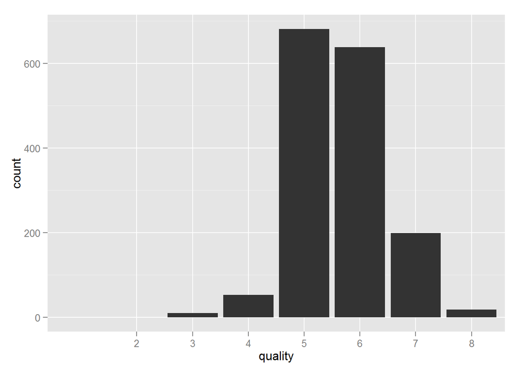

We notice that quality is an integer value. Furthermore, we notice that the data is normally distributed with the peaks at a quality of 5 and 6.

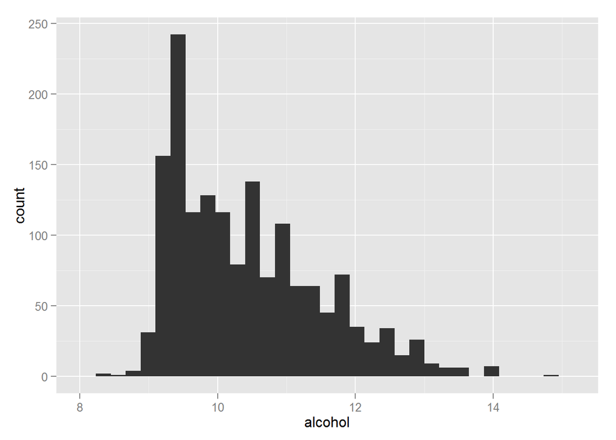

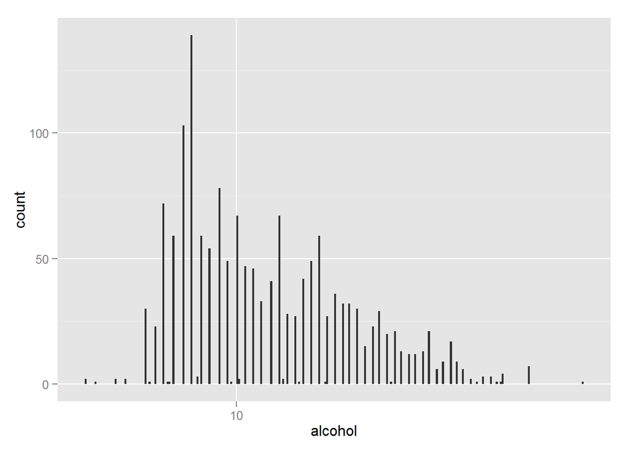

I log transformed the data in order to better understand it. The alcohol looks skewed with a right tail distribution. The mean of the alcohol percentage is 10.42. There also appears to be a second peak when looking at the log transformation graph.

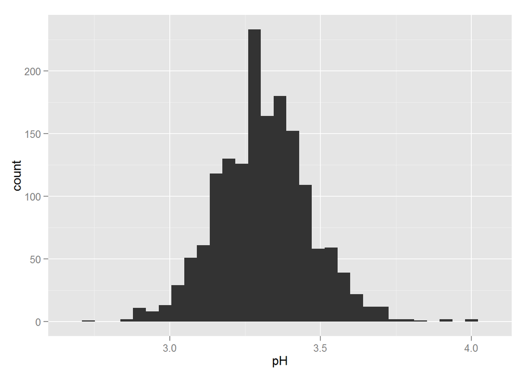

Looking at this graph, it is easy to see that the pH of red wines is normally distributed. The peak looks like it happens around 3.3.

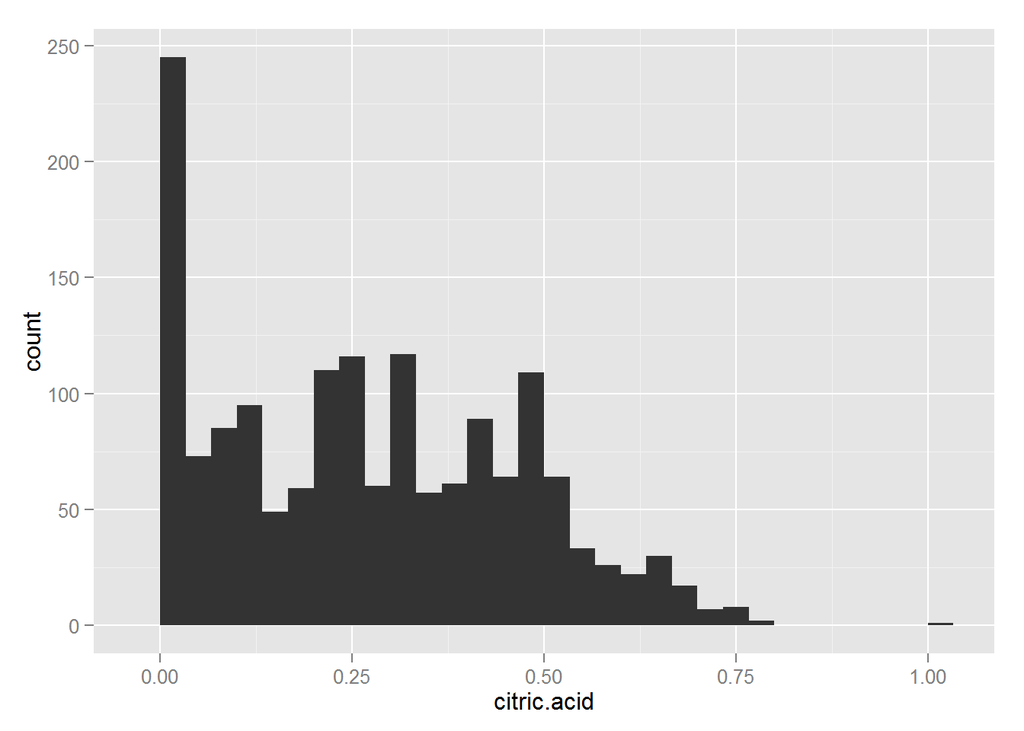

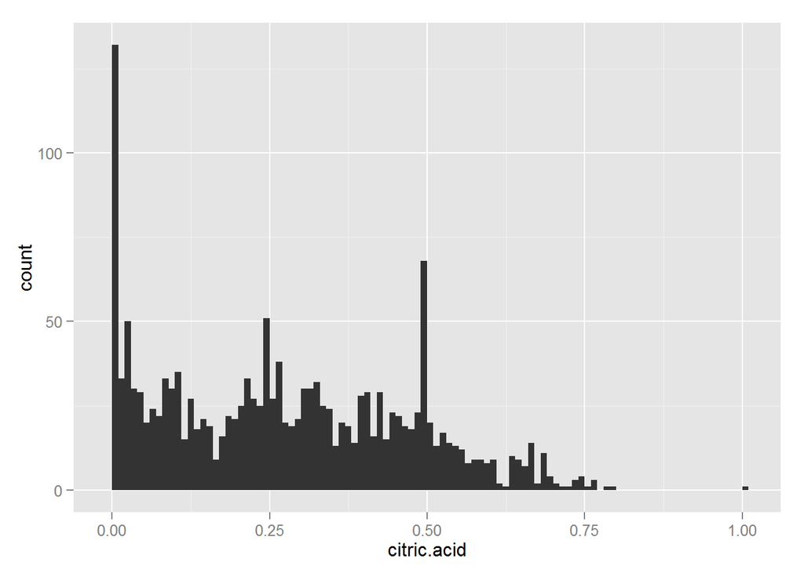

Citric acid for the most part is evenly distributed becides the two peaks that are noticed at 0.00 and 0.49. After the second peak at 0.49, the data seems to appear much less frequently.

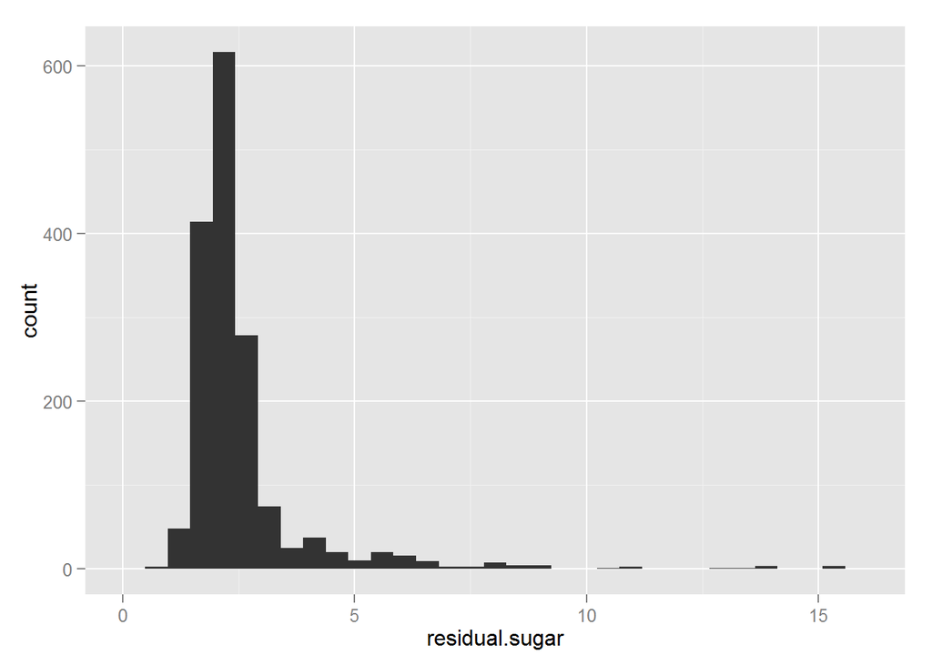

It appears that residual.sugar is concentrated at values below 5. It evenly looks normally distributed if one were to only see values of 0 to 5 for residual sugar. Beyond a value of 5, there are very little counts and after 10 even less.

# Univariate Analysis

### What is the structure of your dataset?

There are 1,599 red wines in the dataset with 12 features: fixed acidity, volatile acidity, citric acid, residual sugar, chlorides, free sulfur dioxide, total sulfur dioxide, density, pH, sulphates, alcohol, quality (note that the column X can be ommitted as this does not provide value). The variable quality is an integer value ranging from 3 to 8.

Other observations: Most red wines have a residual sugar of 5 or less. The median alcohol percentage is 10.20. Free sulfure dioxide has 75% less than 21; however the max is 72, which could just be an outlier. The median quality of a red whine is 6 while the max is 8.

### What is/are the main feature(s) of interest in your dataset?

My main feature of interest in my dataset is the quality. I want to see if any variables impact the overall quality of the red wine.

### What other features in the dataset do you think will help support your investigation into your feature(s) of interest?

I think that the alcohol percentage will play a significant role in the quality of the wine. Furthermore, by looking at the definitions of each column, I believe that volatile acidity will play a role since when too high it will give wine a vinegar taste which would lead to a lower quality score. I also believe that citric acid will play a role as it can add “freshness” to the wine.

### Did you create any new variables from existing variables in the dataset?

No I did not.

### Of the features you investigated, were there any unusual distributions? Did you perform any operations on the data to tidy, adjust, or change the form of the data? If so, why did you do this?

I did not tidy the data, but I did remove the X variable. I removed the X variable since it was an identifier and did not bring value to the data and would have hindered on the bivariate analysis.

# Bivariate Plots Section

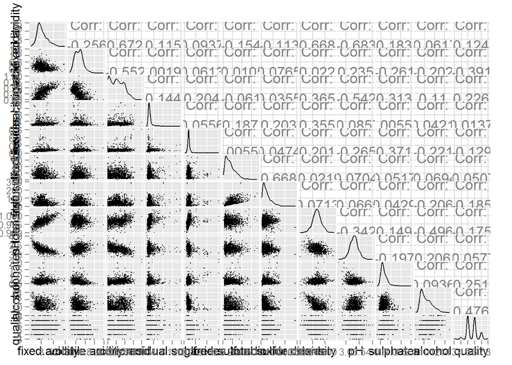

```
##                      fixed.acidity volatile.acidity   citric.acid
## fixed.acidity          3.031416389    -7.985142e-02  0.2278200037
## volatile.acidity      -0.079851417     3.206238e-02 -0.0192716208
## citric.acid            0.227820004    -1.927162e-02  0.0379474831
## residual.sugar         0.281756262     4.841910e-04  0.0394342700
## chlorides              0.007678692     5.165869e-04  0.0018687248
## free.sulfur.dioxide   -2.800921493    -1.967359e-02 -0.1242521139
## total.sulfur.dioxide  -6.482345858     4.504257e-01  0.2276972740
## density                0.002195224     7.443665e-06  0.0001341746
## pH                    -0.183585704     6.494699e-03 -0.0162975823
## sulphates              0.054010092    -7.921434e-03  0.0103277145
## alcohol               -0.114421153    -3.860022e-02  0.0228151729
## quality                0.174423588    -5.647588e-02  0.0356118929
##                      residual.sugar     chlorides free.sulfur.dioxide
## fixed.acidity          0.2817562623  7.678692e-03       -2.800921e+00
## volatile.acidity       0.0004841910  5.165869e-04       -1.967359e-02
## citric.acid            0.0394342700  1.868725e-03       -1.242521e-01
## residual.sugar         1.9878971330  3.690176e-03        2.758611e+00
## chlorides              0.0036901759  2.215143e-03        2.738303e-03
## free.sulfur.dioxide    2.7586114522  2.738303e-03        1.094149e+02
## total.sulfur.dioxide   9.4164414790  7.338675e-02        2.297375e+02
## density                0.0009454109  1.782176e-05       -4.332504e-04
## pH                    -0.0186442890 -1.925745e-03        1.136531e-01
## sulphates              0.0013209414  2.961878e-03        9.159247e-02
## alcohol                0.0632189598 -1.109152e-02       -7.736984e-01
## quality                0.0156350457 -4.899545e-03       -4.279071e-01
##                      total.sulfur.dioxide       density            pH
## fixed.acidity               -6.482346e+00  2.195224e-03 -1.835857e-01
## volatile.acidity             4.504257e-01  7.443665e-06  6.494699e-03
## citric.acid                  2.276973e-01  1.341746e-04 -1.629758e-02
## residual.sugar               9.416441e+00  9.454109e-04 -1.864429e-02
## chlorides                    7.338675e-02  1.782176e-05 -1.925745e-03
## free.sulfur.dioxide          2.297375e+02 -4.332504e-04  1.136531e-01
## total.sulfur.dioxide         1.082102e+03  4.424727e-03 -3.376988e-01
## density                      4.424727e-03  3.562029e-06 -9.956395e-05
## pH                          -3.376988e-01 -9.956395e-05  2.383518e-02
## sulphates                    2.394710e-01  4.750962e-05 -5.146186e-03
## alcohol                     -7.209298e+00 -9.979518e-04  3.383162e-02
## quality                     -4.917237e+00 -2.666037e-04 -7.197822e-03
##                          sulphates       alcohol       quality
## fixed.acidity         5.401009e-02 -0.1144211534  0.1744235876
## volatile.acidity     -7.921434e-03 -0.0386002214 -0.0564758833
## citric.acid           1.032771e-02  0.0228151729  0.0356118929
## residual.sugar        1.320941e-03  0.0632189598  0.0156350457
## chlorides             2.961878e-03 -0.0110915178 -0.0048995449
## free.sulfur.dioxide   9.159247e-02 -0.7736984004 -0.4279070696
## total.sulfur.dioxide  2.394710e-01 -7.2092978950 -4.9172370717
## density               4.750962e-05 -0.0009979518 -0.0002666037
## pH                   -5.146186e-03  0.0338316166 -0.0071978223
## sulphates             2.873262e-02  0.0169067772  0.0344134084
## alcohol               1.690678e-02  1.1356473950  0.4097890108
## quality               3.441341e-02  0.4097890108  0.6521684000
```

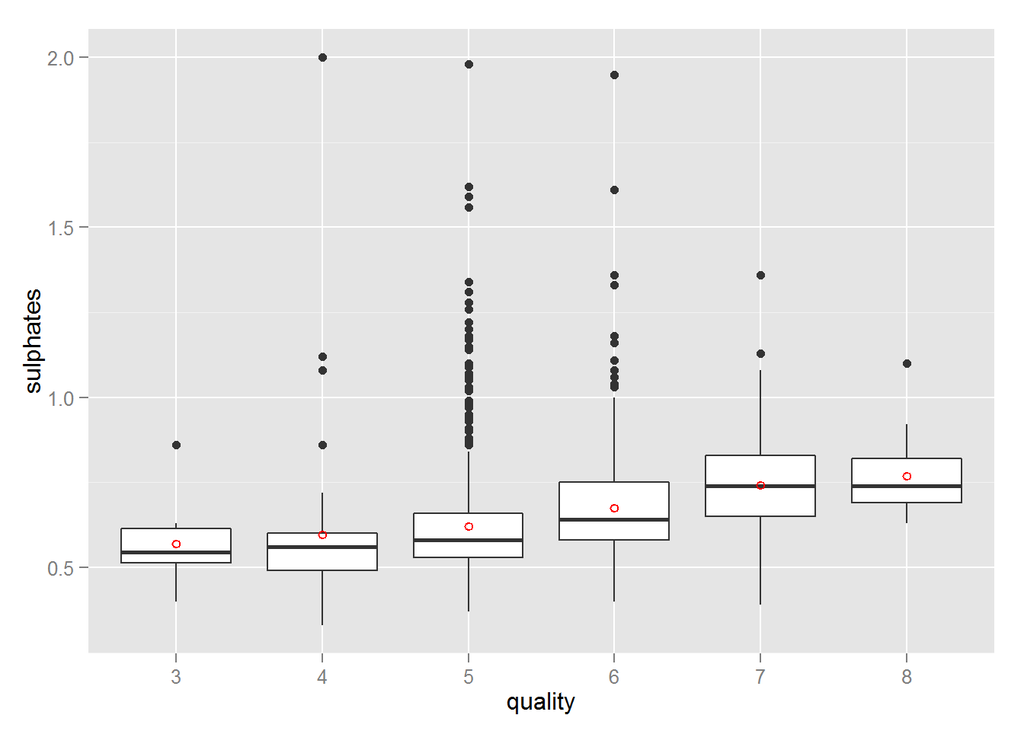

By looking at this boxplot, it is easy to notice that a higher quality results in a higher sulphate level. This can be seen by the upwards shift of both the boxes and the median for each quality level. Furthermore, I have added a red point showing the mean, which also follows a similar trend. A quality of 5 has a lot of outlier points. It is also the quality with the most data points.

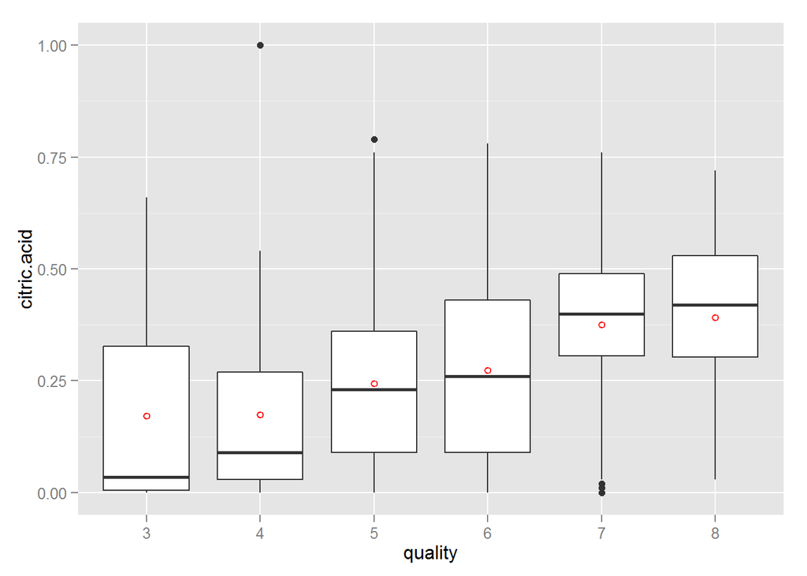

Looking at this graph, a similar upwards trend can be noticed. It appears that the quality gets paired up, as we notice 3 and 4 have similar box plots, as well as 5 and 6 and then 7 and 8. This is consistent with the knowledge that citric acid can add freshness to the wine.

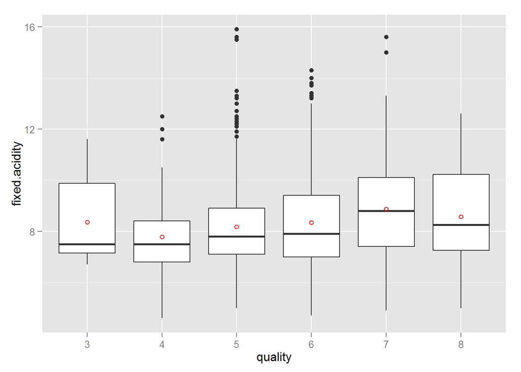

Looking at this graph, it appears that the fixed acidity does not change much when the quality of wine changes. For a quality of 3 or 4, it appears the medians sit under a fixed acidity of 8. For a quality of 5 or 6, the medians sit at about a fixed acidity of 8. For a quality of 7 and 8, the medians sit above a fixed acidity of 8.

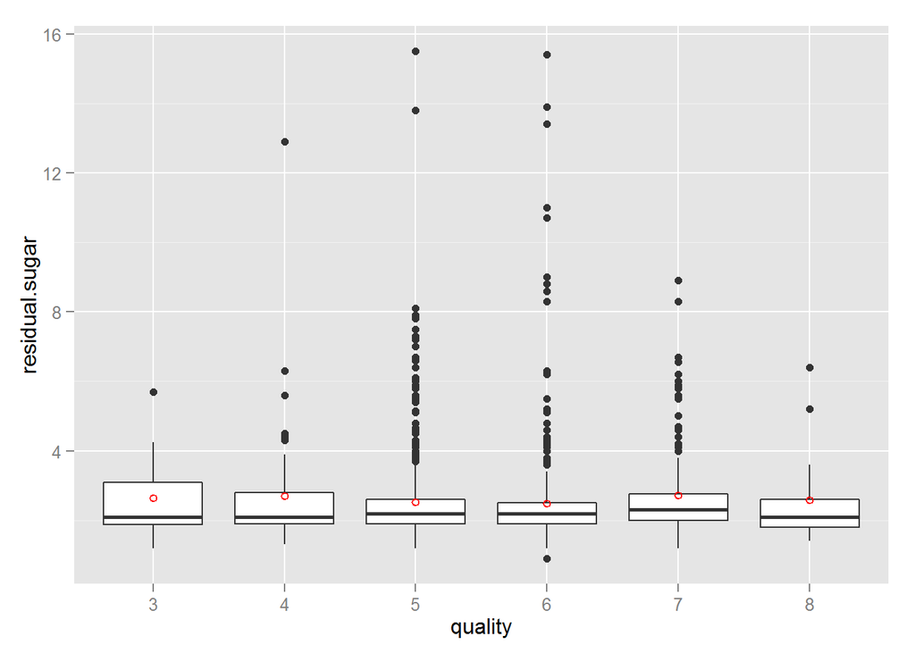

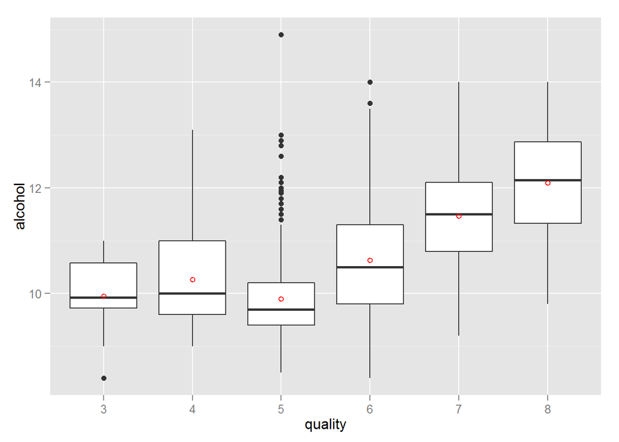

This graph is interesting. At the lower end of the quality, there is a slight decrease from 4 to 5 in the alcohol percentage. However, 5 and onwards we notice a somewhat linear growth in the median of the alcohol percentage. It also appears that both a quality of 4 and 5 have higher means than their medians while for the other qualities these two values are pretty much similar.

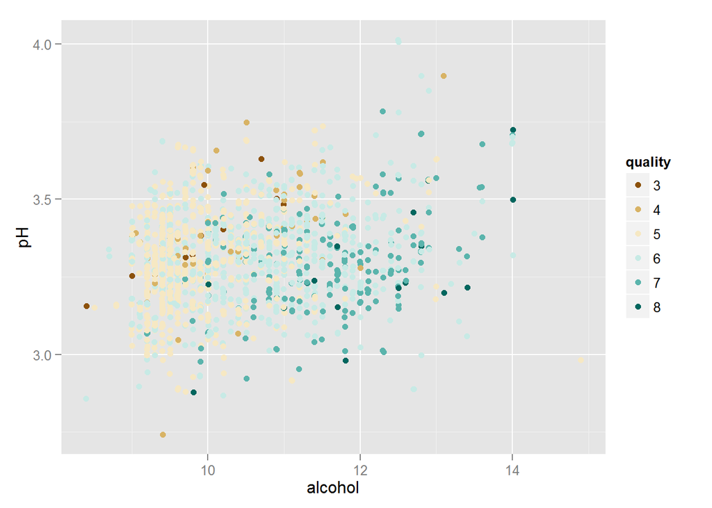

Looking at this scatter plot, it does not look like pH plays a role in the alcohol percentage as the points seem scattered about.

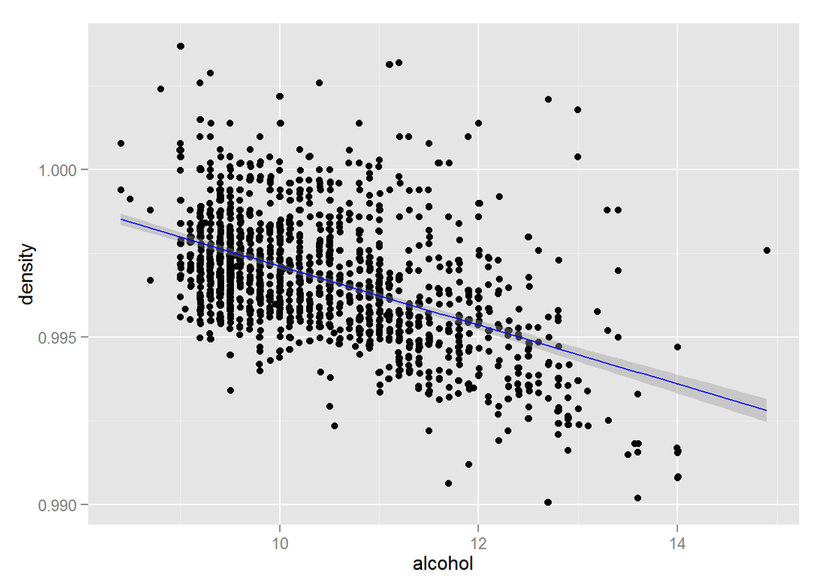

A negative linear relationship can be seen here. By looking at the definition of the density, this makes sense since as alcohol percentage goes up, then the density will be lower since alcohol has a lower density than water.

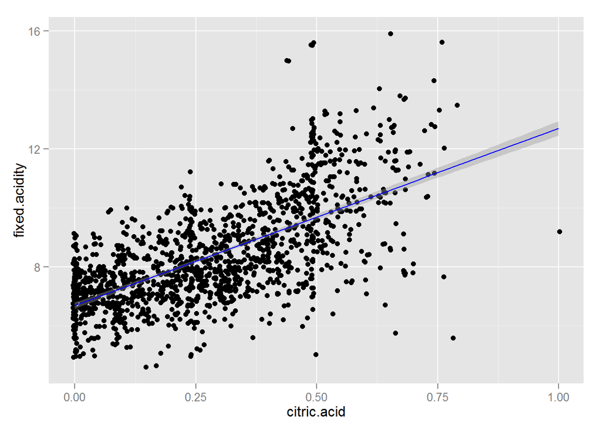

A linear relationship can be examined between citric acid and fixed acidity. Looking at the definition of fixed acidity: most acids involved with wine or fixed or nonvolatile (do not evaporate readily). Thus citric acid appears to be sort of a subgroup of fixed acidity. Therefore, this linear relationship makes sense.

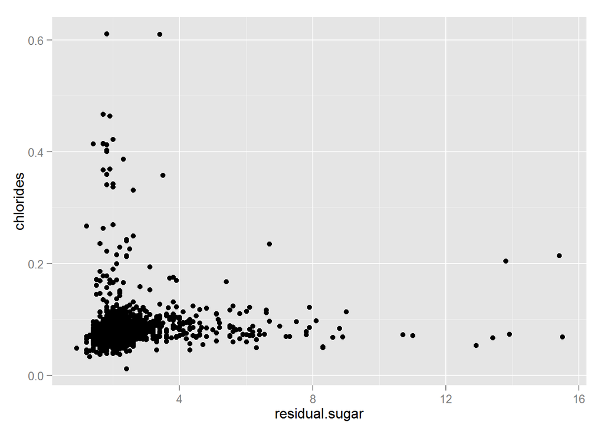

This graph’s shape is interesting. Most of the concentration of points appear in the bottom left corner of the graph. However, then the shape of the points appears to make an L shape, with some points lying at a higher chloride level and lower residual sugar as well as points lying at higher residual sugar levels and lower chloride levels.

# Bivariate Analysis

### Did you observe any interesting relationships between the other features (not the main feature(s) of interest)?

I looked at a few relationships between the other features. What was surprising to me was when I looked at residual sugar vs chlorides. In the plot, at the lower end of the residual sugar (at about 2) there appears to be the majority of the points. Furthermore, there are quite a few points that have a chloride of 0.2 or higher. As we move along right of the graph (a higher residual sugar) the points tend to be fewer and also almost all fall under a chloride of 0.2. Chlorides specifies the amount of salt in the wine. Therefore, it is interesting that the presence of sugar can result in a smaller chloride.

### What was the strongest relationship you found?

The strongest relationship that I found was that the quality of wine is positively and strongly correlated with alcohol percentage. Sulphates and citric acid are also positievly correlated to quality but not as much as alcohol was.

# Multivariate Plots Section

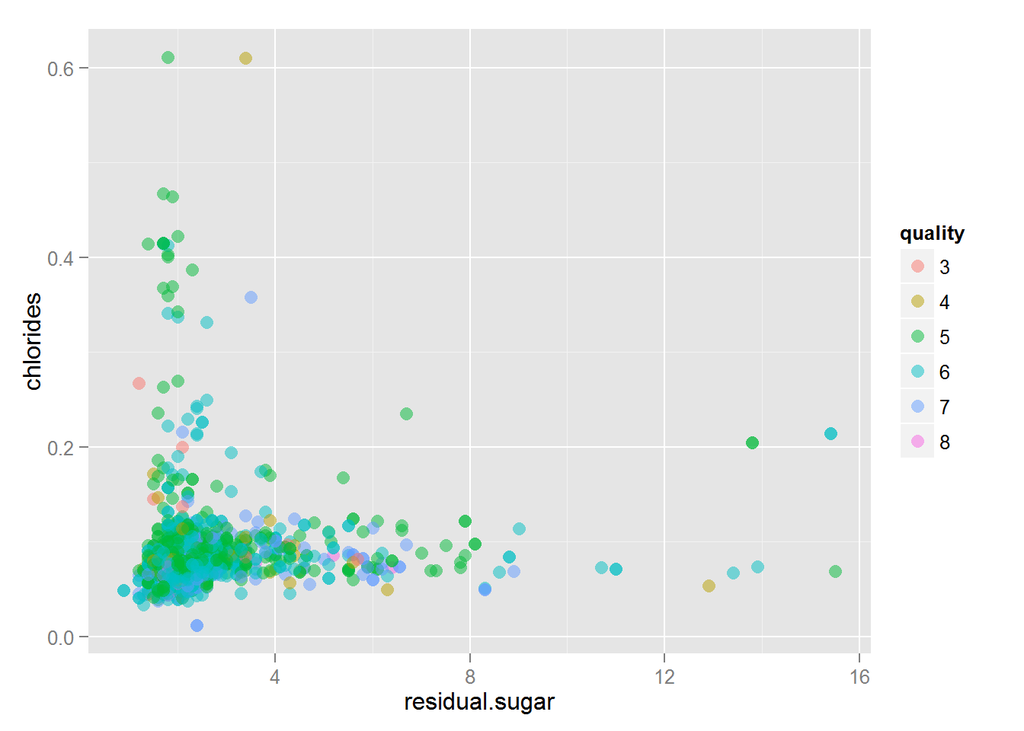

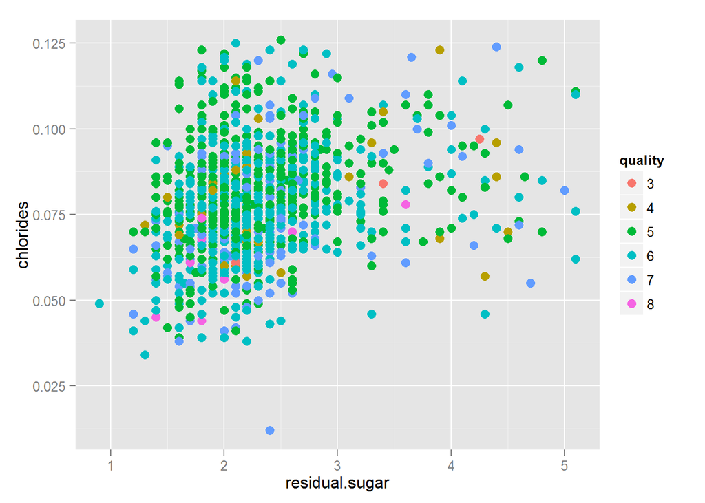

The first graph contains all the points. In the second graph, I decided to look at the 95% quantile to eliminate the outliers. Looking at this plot, we do not see too much of a pattern. It appears that quality of 8 appears to have lower chlorides, but there are very few points of quality 8 so it is not clear if this is a good depection of it.

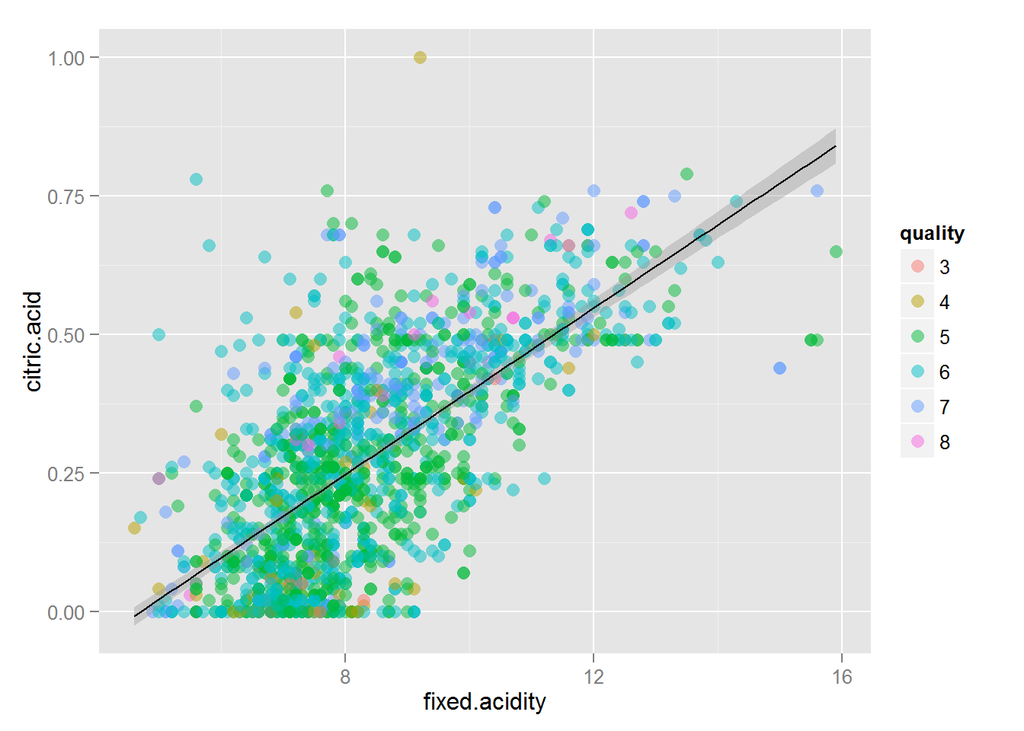

Looking at this plot, I have added a smooth conditional mean. On the under side of the line it appears there is a greater concentration of green and brown values which represents the lower quality; while above the line it appears there is a greater quantity of blue and purple values which represents a quality of 6 and above. Thus it appears that a higher citric acid tends to lead to a higher quality as long as the fixed acidity increases as well.

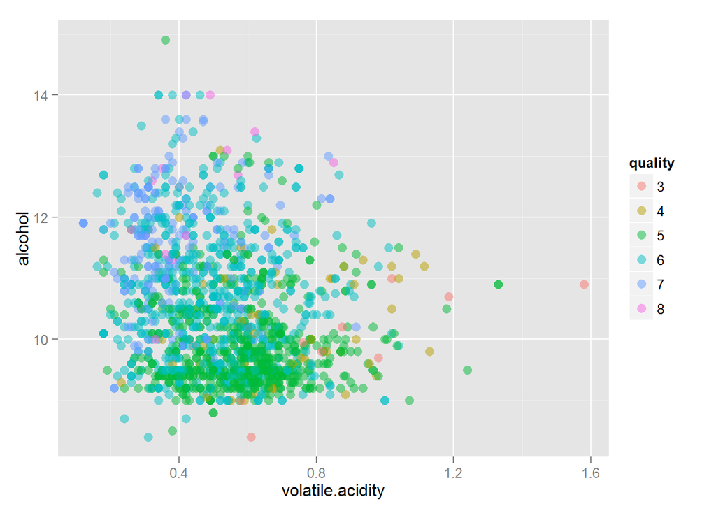

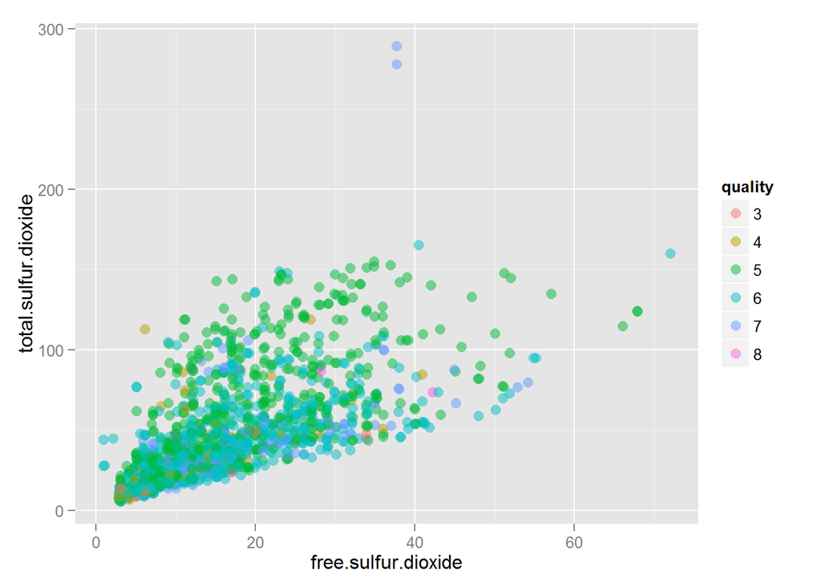

Looking at this graph, it looks as if a higher total sulfur dioxide tends to have a more greenish and brown feel which represents the lower qualities.

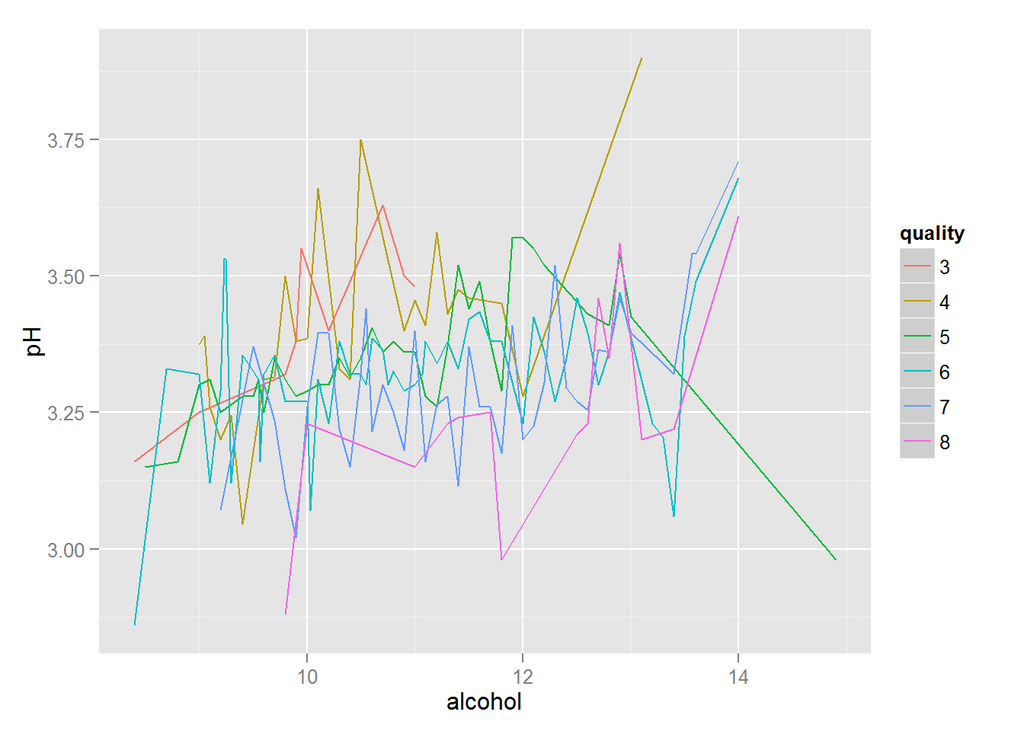

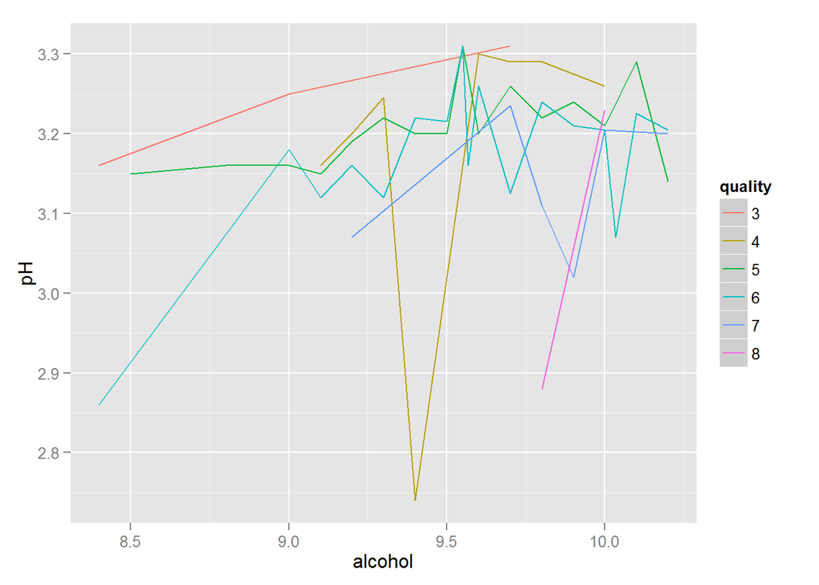

Looking at the first graph, it is apparent that not much can be said. So I decided to look at a smaller set of the data with a quantile of .50. Here it appears that the lowest quality sits at the highest pH level of 3.2 to 3.3. Then it appears that for the higher qualities of 6,7,8 they all start at a low pH and then tend to move upwards as alcohol goes up. Most of the lines appear to reside in the upper half of the graph.

```
##
## Calls:
## m1: lm(formula = I(quality2) ~ I(alcohol), data = wines)
## m2: lm(formula = I(quality2) ~ I(alcohol) + sulphates, data = wines)
## m3: lm(formula = I(quality2) ~ I(alcohol) + citric.acid, data = wines)
## m4: lm(formula = I(quality2) ~ I(alcohol) + fixed.acidity, data = wines)
## m5: lm(formula = I(quality2) ~ I(alcohol) + residual.sugar, data = wines)
##
## =================================================================
##                    m1        m2        m3        m4        m5
## -----------------------------------------------------------------
## (Intercept)      1.875***  1.375***  1.830***  1.206***  1.882***
##                 (0.175)   (0.177)   (0.171)   (0.196)   (0.176)
## I(alcohol)       0.361***  0.346***  0.346***  0.368***  0.361***
##                 (0.017)   (0.016)   (0.016)   (0.016)   (0.017)
## sulphates                  0.994***
##                           (0.102)
## citric.acid                          0.730***
##                                     (0.090)
## fixed.acidity                                  0.071***
##                                               (0.010)
## residual.sugar                                          -0.004
##                                                         (0.013)
## -----------------------------------------------------------------
## R-squared           0.227     0.270     0.257     0.250     0.227
## adj. R-squared      0.226     0.269     0.256     0.249     0.226
## sigma               0.710     0.690     0.696     0.700     0.711
## F                 468.267   294.988   276.595   266.512   234.040
## p                   0.000     0.000     0.000     0.000     0.000
## Log-likelihood  -1721.057 -1675.142 -1688.711 -1696.248 -1721.016
## Deviance          805.870   760.894   773.917   781.248   805.829
## AIC              3448.114  3358.284  3385.421  3400.496  3450.031
## BIC              3464.245  3379.793  3406.930  3422.004  3471.540
## N                1599      1599      1599      1599      1599
## =================================================================
```

I decided to do a linear model without expecting much. From the graphs above, no clear linear model could be found. Looking at the results of this linear model, it affirms my thoughts.

# Multivariate Analysis

### Talk about some of the relationships you observed in this part of the investigation. Were there features that strengthened each other in terms of looking at your feature(s) of interest?

In my research, it became clear that alcohol has a strong influence on the quality of wine. While looking at alcohol and volatile acidity, a pattern could be seen that higher quality wines tended to have a higher alcohol percentage and a lower volatile acidity. This could be taken a step further by drawing ellipses around the data of each quality. It is provided below as one of my final plots. From here, it is apparent that the higher quality wines live in the upper left corner.

Furthermore, while looking at the other relationships, it was hard to make any clear pattern. It appears that while looking at the citric acid and fixed acidity plots, it can be seen that a lower citric acid tends to have a lower quality.

### Were there any interesting or surprising interactions between features?

I thought that the graph plotting alcohol vs pH was interesting. I would have sought that these two variables would have played a more significant role in the quality of wine. However, it looks like the pH level does not affect the quality of wine that much. I also liked the graph plotting volatile acidity vs alcohol, as it is easily visible by the color pattern that wines of higher quality sit in the upper left corner where alcohol percentage is higher and volatile acidity is lower.

### OPTIONAL: Did you create any models with your dataset? Discuss the strengths and limitations of your model.

Yes I did using alcohol percentage and quality of wine. The only reason I decided to do this linear model was for knowledge. From doing it, I could tell that a linear model is not the best choice for describing this data. Furthermore, the dataset is quite small at 1599, and thus could lead to a poor model as well.

# Final Plots and Summary

### Plot One

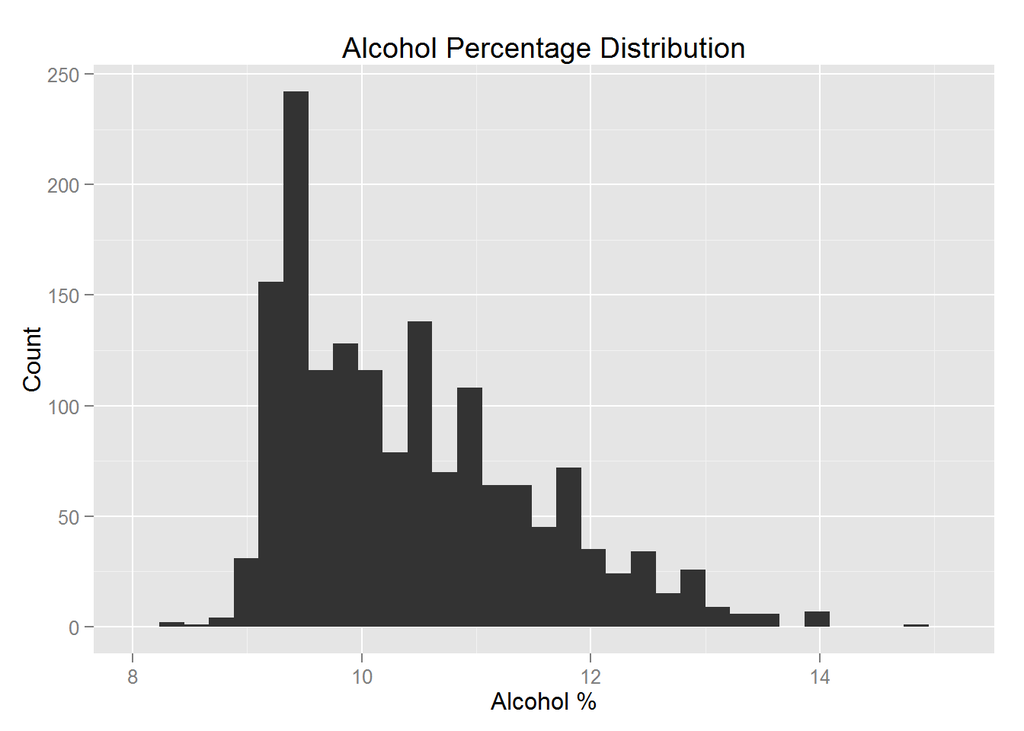

### Description One

I decided to look at the distribution of the alcohol percentage across the red wines. It was interesting to notice that this is a right tailed distribution, with the majority of the count falling at the lower end of the alcohol percentage range. It looks like alcohol percentage ranges from 8 to 15. It is also interesting that between 8 and 9, there is very little count, and then at 9 it shoots up rapidly. Then it progressively dies out as the alcohol percentage reachs 13.

### Plot Two

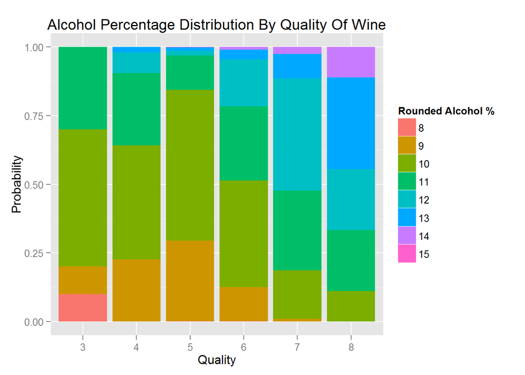

### Description Two

This plot depicts the distribution of alcohol percentage categorized by quality level. It is clear that there is a relationship between alcohol percentage and quality of wine. On the lower end at a quality of 3, it appears that almost 75% of the red wines have an alcohol level of 10 or less (10.5 since it was rounded). As it goes up in quality, a trend is seen where the higher qualities slowly tend to dominate the distribution more. At a quality of 6, only about 50% of the red wines have an alcohol percentage of 10 or less (10.5). Now at the highest quality of 8, only about 10% of the wines have an alocohol percentage of 10 or less. Clearly, it can be understood that as the quality goes up, you are more likely to find higher alcohol percentage wines.

### Plot Three

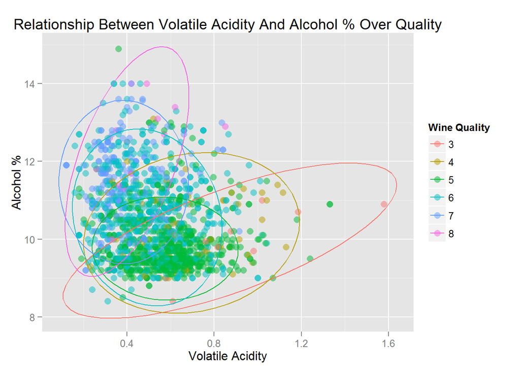

### Description Three

A higher alcohol percentage and lower volatile acidity tends to lead to a higher quality of wine. The ellipses overlayed on this graph clearly depicts this trend. It looks like red wines of quality 6 or better has a volatile acidity range from about 0.2 to just under 0.8. Furthermore, it is known that when volatile acidity is at too high of levels, it can lead to an unpleasant, vinegar taste.

# Reflection

Analyzing this data was quite fun. Being from France myself, wine has always been a big part of the lifestyle. Thus, it made analyzing this data even that more exciting. While I was not able to find a great model to describe the quality of a wine, I did find some interesting observations.

I believe that if I had more data, I would have been able to produce a better model. The data set I looked at only contained 1599 wines, which is not that big of a dataset. Furthermore, besides the number of data points, I also believe other types of information would have been useful. I know that the year produced usually always has a huge impact on the quality, yet that was not provided. Other items I feel would have played a big role are the region where the wine was produced, how old the roots that produced the grapes were, the types of grape, and the producer.

It was very interesting getting to study the checmical properties of a wine and there effect on the quality of a wine. I found it amusing that a higher alcohol percentage leads to a better quality of wine. I would have thought that some of the other factors would have had a higher correlation such as amount of sugar. From listening to my family, and from personal experience, I know many people that disliked sweeter wines. However, from analyzing this data, I did not reach this conclusion.

I believe another study that would be interesting, is categorizing the wines by region. It would be interesting to see how variables affect the quality of wines broken down into region. Furthermore, I believe that it would be interesting to get a variety of judges from different regions and even countries. I do realize that in this dataset the quality is the average score of three judges; however, it would be interesting to be able to compare a score given by judges in one region vs judges in another region.